# Leachate Analysis from 2025 Greenhouse Study

### 2.4.4 Tukey Test

There were no significant differences among treatment groups for nitrate or phosphate concentrations in leachate.

For ammonium, there were significant concentration differences between the following treatments (along with p adj values):

- Fertilizer-SL_Empty_Bead 0.0020809
- Fertilizer-SL_BioBead_AMF 0.0001264
- Fertilizer-SL_BioBead_Mixed 0.0002748
- Fertilizer-Liquid_Mixed 0.0027988
- Fertilizer-Negative 0.0027988
- Fertilizer-Empty_Bead 0.0001212

### 2.4.5 Shapiro Wilk test for normality

```
##
##  Shapiro-Wilk normality test
##
## data:  anova_NH4_wk8$residuals
## W = 0.72636, p-value = 3.185e-12
```

```
##
##  Shapiro-Wilk normality test
##
## data:  anova_NO3_wk8$residuals
## W = 0.74704, p-value = 1.064e-11
```

```
##
##  Shapiro-Wilk normality test
##
## data:  anova_PO4_wk8$residuals
## W = 0.87171, p-value = 1.038e-07
```

Similar to previous weeks, there are similarly very low p values. This indicates that the data are not normal.

### 2.4.6 Residuals distribution

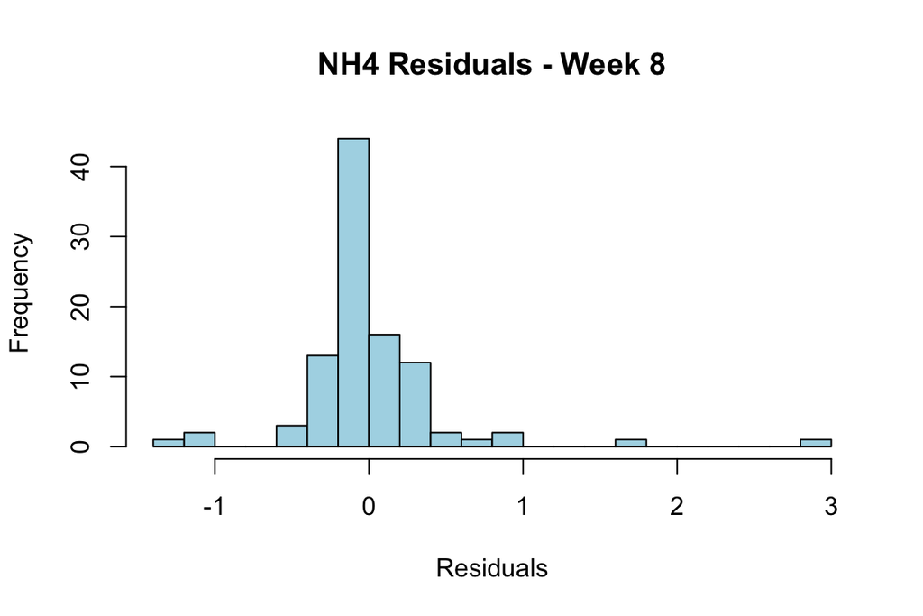

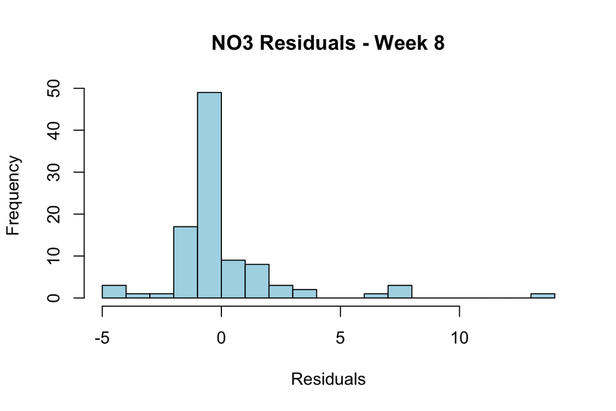

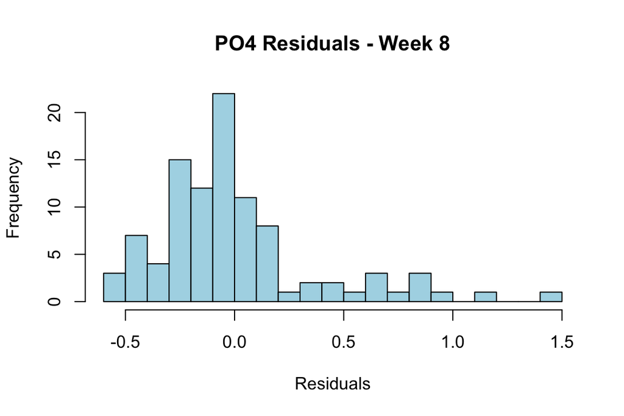

### 2.4.7 Quantile-Quantile plots

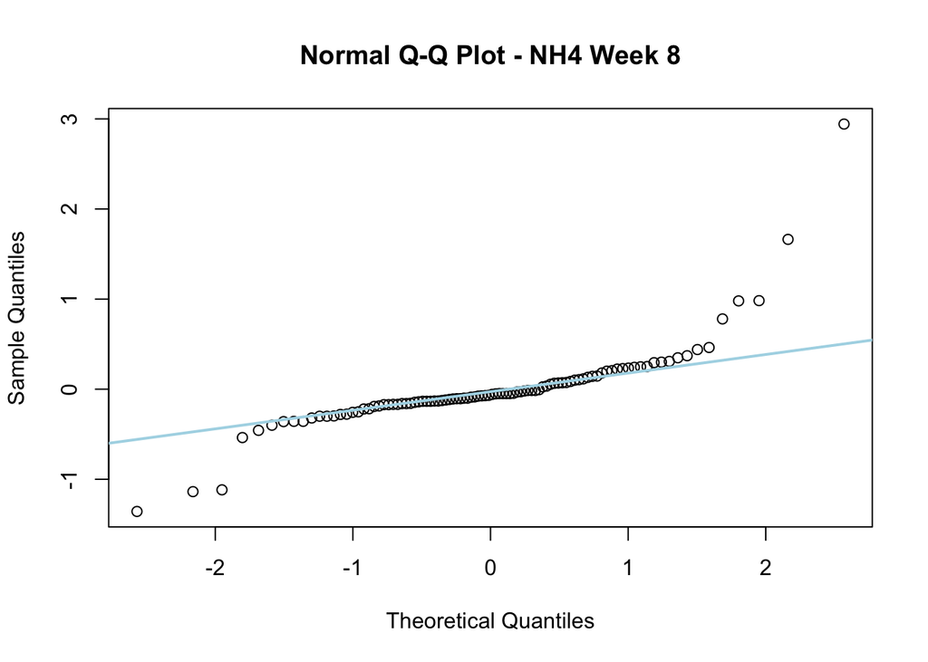

```r
qqnorm(anova_NH4_wk8$residuals, main = "Normal Q-Q Plot - NH4 Week 8")
qqline(anova_NH4_wk8$residuals, col = "lightblue", lwd = 2)
```

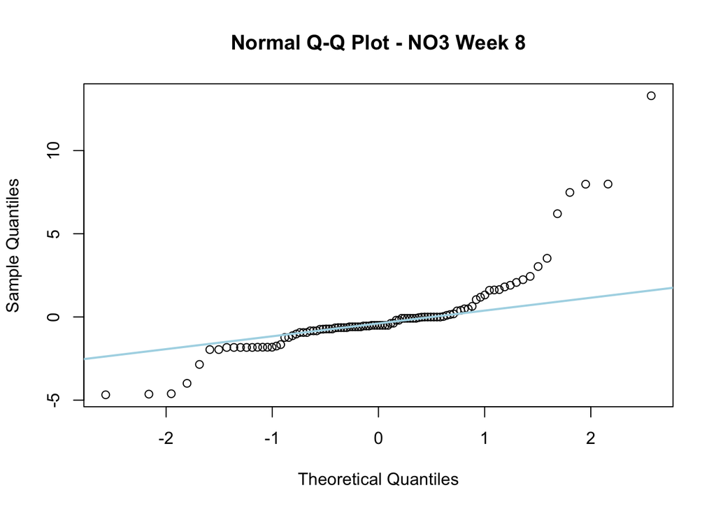

```r
qqnorm(anova_NO3_wk8$residuals, main = "Normal Q-Q Plot - NO3 Week 8")
qqline(anova_NO3_wk8$residuals, col = "lightblue", lwd = 2)
```

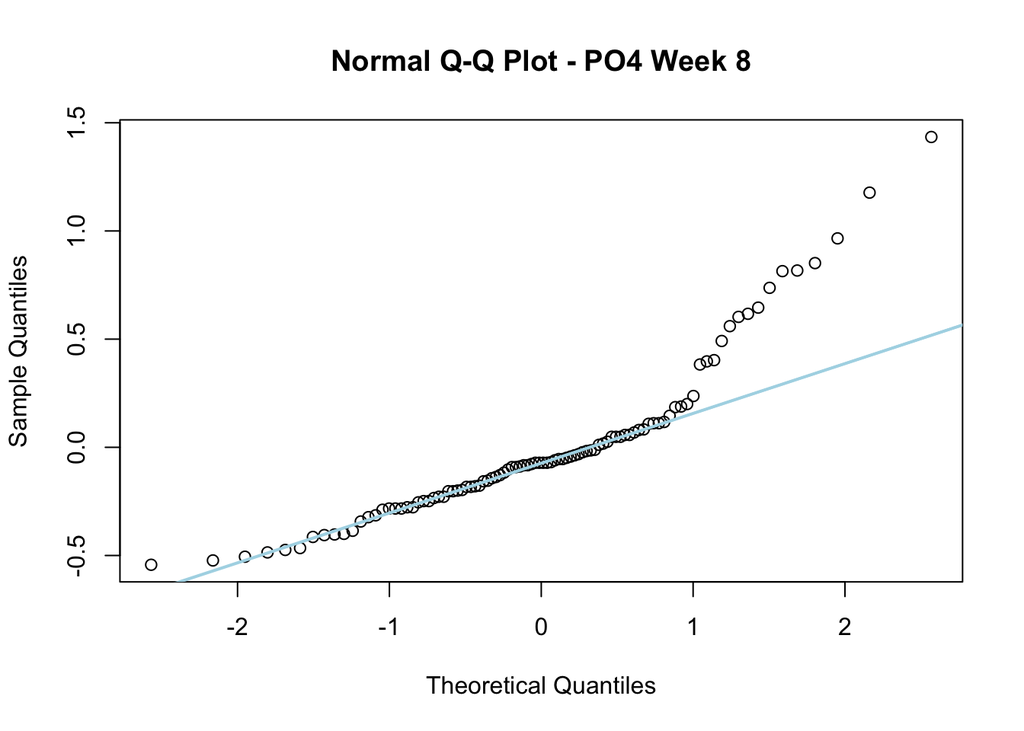

```r
qqnorm(anova_PO4_wk8$residuals, main = "Normal Q-Q Plot - PO4 Week 8")
qqline(anova_PO4_wk8$residuals, col = "lightblue", lwd = 2)
```

# 3 Discussion

Leachate data is not normally distributed, hence ANOVA is not the appropriate statistical approach. Regardless, we start to see signal at week 8 with ammonium concentrations. These are mostly comparisons to synthetic fertilizer, which is expected.

## 3.1 Next steps

- Use alternative to ANOVA, like Non-Parametric Tests (Kruskal-Wallis) or Linear Mixed Effects Model
- Consider data transformation (e.g. relativizing to max) to address normality issues
- Consider multivariate approaches to connect with other data (soil moisture, greenhouse gases, soil ions)